# R Notebook

Download the file MarketShare.csv then write an R Notebook document that will contain the R codes and answers to the following problems.

```r
dat <- read.csv("MarketShare.csv")
```

1. Fit a linear regression model that can be used to predict CustomerSatisfaction based on MarketShare. Interpret the estimate of the slope and intercept of the model.

```r
modCS <- lm(CustomerSatisfaction ~ MarketShare, dat)
summary(modCS)
```

```
Call:
lm(formula = CustomerSatisfaction ~ MarketShare, data = dat)

Residuals:
     Min       1Q   Median       3Q      Max
-0.60800 -0.34142 -0.04142  0.27529  1.03985

Coefficients:
            Estimate Std. Error t value Pr(>|t|)
(Intercept)  8.39331    0.70144  11.966 2.16e-08 ***
MarketShare -0.17291    0.02339  -7.394 5.24e-06 ***
---
Signif. codes:  0 ‘***’ 0.001 ‘**’ 0.01 ‘*’ 0.05 ‘.’ 0.1 ‘ ’ 1

Residual standard error: 0.4745 on 13 degrees of freedom
Multiple R-squared:  0.8079,    Adjusted R-squared:  0.7931
F-statistic: 54.67 on 1 and 13 DF,  p-value: 5.24e-06
```

- The model has an intercept of 8.39331, meaning when the value of market share is 0, customer satisfaction is at a level of 8.39331. The slope of the model is -0.17291, meaning that for each increase in the value of the market share by 1, the customer satisfaction will decrease by -0.17291.
2. Is MarketShare a statistically significant predictor of CustomerSatisfaction? Justify by citing an appropriate statistic from the regression summary.
- The value of the coefficient of determination, R-Squared, is .8079 meaning that 80.79% of our customer satisfaction variance can be explained using this model. This is a statistically significant model and would be an appropriate model to predict customer satisfaction based on market share.
3. Plot the residuals after fitting the model in #1. Do the residuals appear to be white noise? Verify with an ACF plot.

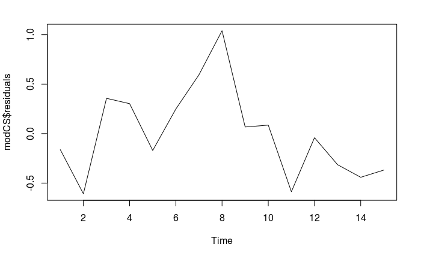

```r
plot.ts(modCS$residuals)
```

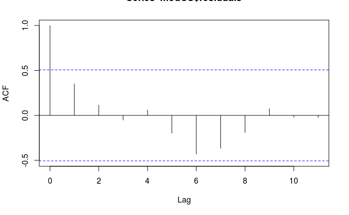

```r
acf(modCS$residuals)
```

- Based on the plot of the residuals and the ACF plot, we are led to believe that the residuals follow a white noise distribution.
4. What can we conclude if the residual is a white noise?
- We can conlude that the model fits the data well.
5. Fit a linear regression model that can be used to predict CustomerSatisfaction at time t based on MarketShare at time t-1. Which is a better predictor of CustomerSatisfaction at time t, is it MarketShare at time t or the lag 1 Marketshare? Explain.

```r
modCSLag <- lm(dat$CustomerSatisfaction[2:15] ~ dat$MarketShare[1:14])
summary(modCSLag)
```

```
Call:
lm(formula = dat$CustomerSatisfaction[2:15] ~ dat$MarketShare[1:14])

Residuals:
    Min      1Q  Median      3Q     Max
-0.4158 -0.2412 -0.1232  0.1466  0.8724

Coefficients:
                      Estimate Std. Error t value Pr(>|t|)
(Intercept)            8.36595    0.59197  14.132 7.67e-09 ***
dat$MarketShare[1:14] -0.17794    0.02005  -8.873 1.28e-06 ***
---
Signif. codes:  0 ‘***’ 0.001 ‘**’ 0.01 ‘*’ 0.05 ‘.’ 0.1 ‘ ’ 1

Residual standard error: 0.3841 on 12 degrees of freedom
Multiple R-squared:  0.8677,    Adjusted R-squared:  0.8567
F-statistic: 78.73 on 1 and 12 DF,  p-value: 1.282e-06
```

```r
summary(modCS)
```

```
Call:
lm(formula = CustomerSatisfaction ~ MarketShare, data = dat)

Residuals:
     Min       1Q   Median       3Q      Max
-0.60800 -0.34142 -0.04142  0.27529  1.03985

Coefficients:
            Estimate Std. Error t value Pr(>|t|)
(Intercept)  8.39331    0.70144  11.966 2.16e-08 ***
MarketShare -0.17291    0.02339  -7.394 5.24e-06 ***
---
Signif. codes:  0 ‘***’ 0.001 ‘**’ 0.01 ‘*’ 0.05 ‘.’ 0.1 ‘ ’ 1

Residual standard error: 0.4745 on 13 degrees of freedom
Multiple R-squared:  0.8079,    Adjusted R-squared:  0.7931
F-statistic: 54.67 on 1 and 13 DF,  p-value: 5.24e-06
```

- The model predicting customer satisfaction using lag 1 market share is better because it has a R-Squared value of .8677 and an adjusted R-Squared value of .8567, while the model without lag has an R-Squared value of .8079 and adjusted R-Squared value of .7931.
6. Do Problem 2.1 from the textbook.

2.1 A Structural Model For the Johnson & Johnson data, say yt , shown in Figure 1.1, let $x_t = log(y_t)$. In this problem, we are going to fit a special type of structural model, $x_t = T_t + S_t + N_t$ where $T_t$ is a trend component, $S_t$ is a seasonal component, and $N_t$ is noise. In our case, time t is in quarters (1960.00, 1960.25, . . . ) so one unit of time is a year.

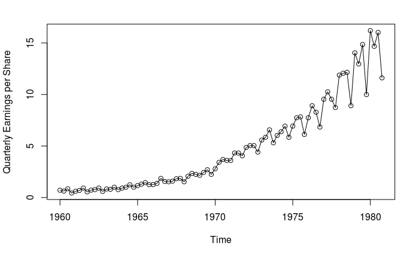

```r
library(astsa) # SEE THE FOOTNOTE
plot(jj, type="o", ylab="Quarterly Earnings per Share")
```

```r
trend = time(jj) - 1970 # helps to 'center' time
Q = factor(cycle(jj) ) # make (Q)uarter factors
reg = lm(log(jj)~0 + trend + Q, na.action=NULL) # no intercept
head(model.matrix(reg)) # view the model design matrix
```

```
   trend Q1 Q2 Q3 Q4
1 -10.00  1  0  0  0
2  -9.75  0  1  0  0
3  -9.50  0  0  1  0
4  -9.25  0  0  0  1
5  -9.00  1  0  0  0
6  -8.75  0  1  0  0
```

```r
summary(reg)
```

```
Call:
lm(formula = log(jj) ~ 0 + trend + Q, na.action = NULL)

Residuals:
     Min       1Q   Median       3Q      Max
-0.29318 -0.09062 -0.01180  0.08460  0.27644

Coefficients:
      Estimate Std. Error t value Pr(>|t|)
trend 0.167172   0.002259   74.00   <2e-16 ***
Q1    1.052793   0.027359   38.48   <2e-16 ***
Q2    1.080916   0.027365   39.50   <2e-16 ***
Q3    1.151024   0.027383   42.03   <2e-16 ***
Q4    0.882266   0.027412   32.19   <2e-16 ***
---
Signif. codes:  0 ‘***’ 0.001 ‘**’ 0.01 ‘*’ 0.05 ‘.’ 0.1 ‘ ’ 1

Residual standard error: 0.1254 on 79 degrees of freedom
Multiple R-squared:  0.9935,    Adjusted R-squared:  0.9931
F-statistic:  2407 on 5 and 79 DF,  p-value: < 2.2e-16
```

2. If the model is correct, what is the estimated average annual increase in the logged earnings per share?

```r
sum(reg$coefficients)
```

```
[1] 4.334172
```

```r
reg$coefficients[4] -reg$coefficients[5] / reg$coefficients[4]
```

```
       Q3
0.3845186
```

```r
head(model.matrix(regWithInt)) # view the model design matrix
```

[output not shown]

```
  (Intercept)  trend Q2 Q3 Q4
1           1 -10.00  0  0  0
2           1  -9.75  1  0  0
3           1  -9.50  0  1  0
4           1  -9.25  0  0  1
5           1  -9.00  0  0  0
6           1  -8.75  1  0  0
```

```r
par(mfrow=c(1,2))
plot(log(jj), main="data and fitted value")
lines(fitted(reg), col="blue")
```

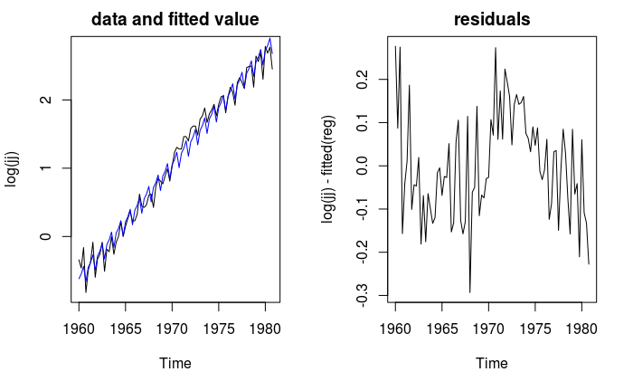

```r
plot(log(jj)-fitted(reg), main="residuals")
```